# MTH6139 Time Series

Coursework 1 – Dota 2

Mingyu Mao (ID:220272551)

16/03/2025

# Section 1: A good chance to make my idea into reality

To be honest, when I first learned about the concept of time series, l immediately thought of the historical data of each game in Steam. These data are so important for the players to decide whether they should buy the game.

**Who can resist the temptation to save money?**

This coursework is quite a good opportunity to turn my idea — conducting a careful analysis of game player data — into reality!

## 1.1 Choose a suitable game and get global data – Dota 2

We all know, time series relies on a large amount of data, better have a long time span.

This is why l choose Dota 2 as the project. There is no better option than **a free-to-play game that came out in 2012** and is still popular today.

It’s not hard to find its peak number of players over the years online. Thanks for the data provided by STEAMCHARTS, you can also check out more game stats online by https://steamcharts.com/

## 1.2 Deal with the data

Although there is no available CSV on these websites and too much data for manual collection, there doesn’t exist a problem that Google can’t solve.

Anyway, just find a website for converting html to CVS online, and import the CSV.

```r
data <- read.csv("data/Dota 2 - Steam Charts.csv") # Read CSV file
head(data) # View the first columns of data to ensure no mistake
```

```
##            Month Peak.Players
## 1      July 2012        75041
## 2    August 2012       108689
## 3 September 2012       118724
## 4   October 2012       171860
## 5  November 2012       169631
## 6  December 2012       213521
```

```r
tail(data) # View the last columns
```

```
##              Month Peak.Players
## 147 September 2024       726385
## 148   October 2024       706726
## 149  November 2024       797599
## 150  December 2024       744163
## 151   January 2025       719825
## 152  February 2025       708043
```

The CSV has months in the format like “July 2012”, which cannot be used directly.

Next step is to convert these into Date by `zoo::as.Date(zoo::as.yearmon(data$Month, format = "%B %Y"))`… Hold on! There is a potential error!

> ⚠️ **Notice**

> It is possible that the result of `zoo::as.Date(zoo::as.yearmon(data$Month, format = "%B %Y"))` can be `<NA>` .

> This because R’s current locale doesn’t recognize the English month name like “July”.

> To solve this problem, we need to force an English-based locale firstly (on windows).

> Run the following: `Sys.setlocale("LC_TIME", "English_United States.1252")`

> It occurred when l tried to run the code and l fight with this error for an hour😭.

> Thanks Google for saving my code once again😭.

Be careful with this potential error! Run `zoo::as.Date(zoo::as.yearmon(data$Month, format = "%B %Y"))` to check whether the date is displayed correctly.

Then we run the code normally

```r
# Since <NA> result will occur when l run the code in my own computer so l add this line here:
Sys.setlocale("LC_TIME", "English_United States.1252")
```

```
## [1] "English_United States.1252"
```

```r
# Convert the values of mouth into Date
data$Month <- zoo::as.Date(zoo::as.yearmon(data$Month, format = "%B %Y"))
# Convert the values of Peak.Players to numeric
data$Peak.Players <- as.numeric(gsub(",", "", data$Peak.Players))

colnames(data) <- c("ds", "y") # time columns are called ds and the data column called y
data <- data
head(data) # View the first columns of data to ensure no mistake
```

```
##           ds      y
## 1 2012-07-01  75041
## 2 2012-08-01 108689
## 3 2012-09-01 118724
## 4 2012-10-01 171860
## 5 2012-11-01 169631
## 6 2012-12-01 213521
```

```r
tail(data) # View the last columns
```

```
##             ds      y
## 147 2024-09-01 726385
## 148 2024-10-01 706726
## 149 2024-11-01 797599
## 150 2024-12-01 744163
## 151 2025-01-01 719825
## 152 2025-02-01 708043
```

## 1.3 Time to make the dataframe!

Finally, all the data are ready. Time to make my own dataframe!

```r
dota2.df = data.frame(data) # save the dataframe as 'dota2.df'
head(dota2.df) # View the first columns of data to ensure no mistake
```

```
##           ds      y
## 1 2012-07-01  75041
## 2 2012-08-01 108689
## 3 2012-09-01 118724
## 4 2012-10-01 171860
## 5 2012-11-01 169631
## 6 2012-12-01 213521
```

```r
tail(dota2.df) # View the last columns
```

```
##             ds      y
## 147 2024-09-01 726385
## 148 2024-10-01 706726
## 149 2024-11-01 797599
## 150 2024-12-01 744163
## 151 2025-01-01 719825
## 152 2025-02-01 708043
```

# Section 2: Analyze the data and see what happens

## 2.1 Using Meta’s Prophet forecasting system.

Following by the tips, let use the prophet to forecast based on these data.

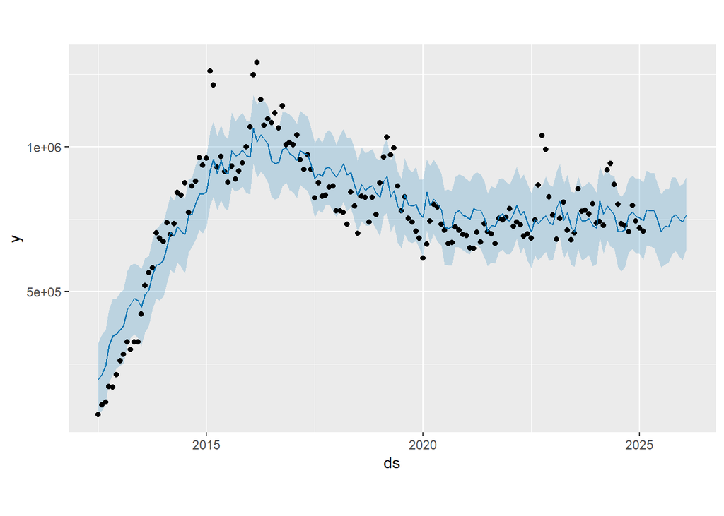

```r
# Fit the prophet model using the dota2 dataset
m = prophet::prophet(dota2.df,
             yearly.seasonality = TRUE, # Since my data is monthly
             weekly.seasonality = FALSE,
             daily.seasonality = FALSE) # Weekly and daily seasonality is disable

# Then make a future dataframe with 12 periods (one year)
f = prophet::make_future_dataframe(m, periods = 12, freq = "month") # one months apart
p = predict(m, f) # Get the predictions for both the historical data and the 12 new months
# plot the original time series data, the model's fitted values and the future forecast
plot(m,p)
```

Occasionally, there area noticeable high peak numbers of players after 2020, combined with real-world news, these peaks likely correspond to interesting updates or new features introduced by the Dota2 game team.

The forecast for the following year supports this, and the overall trend in peak player numbers is expected to remain relatively stable in the coming years.

## 2.2 How about data itself?

The most classic and commonly used function `summary()`are indispensable:

```r
summary(dota2.df) # Check the summary
```

```
##        ds                   y
##  Min.   :2012-07-01   Min.   :  75041
##  1st Qu.:2015-08-24   1st Qu.: 702689
##  Median :2018-10-16   Median : 774108
##  Mean   :2018-10-16   Mean   : 777171
##  3rd Qu.:2021-12-08   3rd Qu.: 895045
##  Max.   :2025-02-01   Max.   :1291328
```

In fact, for a game, a smooth upward curve is very rare – yet Dota2 has really achieved that.

Starting from a low base with only 75,041, the peak number of players grew steadily over the first few years until it reached a impressive 1,291,328

## 2.2 How about trying a line chart?

Let’s bring out our old friend `ggplot()`!

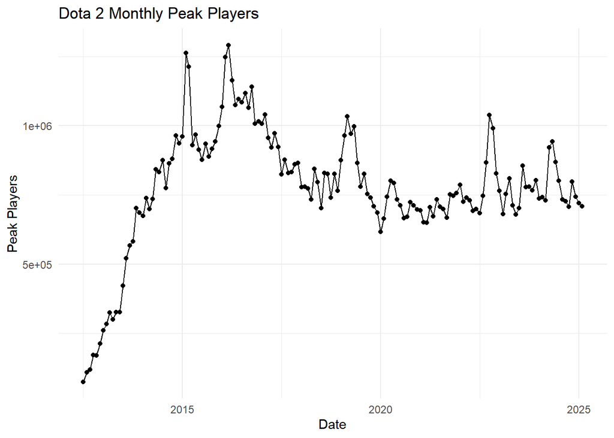

```r
library(ggplot2)
ggplot(dota2.df, aes(x = ds, y = y)) + # 'ds' as x-axis and 'y' as y-axis
    geom_line() + # Add a line connecting data points
    geom_point() + # Draw a point at each data value
    labs(title = "Dota 2 Monthly Peak Players",
         x = "Date",
         y = "Peak Players") +
    theme_minimal()
```

It seems that there is no a clear seasonality here, and its overall trend is also leveling off, as previously predicted.

# Summary

Both this analysis of these real data and my own experience as a player, suggest that Dota2 is still an evergreen in the gaming world, and a predecessor to countless new games. But who knows what the future holds?

Just like I never imagined that I would one day study mathematics at university when l was a kid.